# Risk Factor Analysis

## Outcome Variable

**Outcome Variable:** haz

## Predictor Variables

**Intervention Variable:** mhtcm

**Adjustment Set:**

- arm
- W_mage
- W_fage
- meducyrs
- feducyrs
- single
- W_gagebrth
- W_birthwt
- W_birthlen
- vagbrth
- delta_W_mage
- delta_W_fage
- delta_meducyrs
- delta_feducyrs
- delta_single
- delta_W_gagebrth
- delta_W_birthwt
- delta_W_birthlen
- delta_vagbrth

## Stratifying Variables

The analysis was stratified on these variable(s):

- agecat
- studyid
- country

## Data Summary

| agecat | studyid | country | mhtcm | n_cell | n |
| --- | --- | --- | --- | --- | --- |
| 6 months | COHORTS | GUATEMALA | >=155 cm | 117 | 943 |
| 6 months | COHORTS | GUATEMALA | <151 cm | 629 | 943 |
| 6 months | COHORTS | GUATEMALA | [151-155) cm | 197 | 943 |
| 6 months | COHORTS | INDIA | >=155 cm | 541 | 1819 |
| 6 months | COHORTS | INDIA | <151 cm | 790 | 1819 |
| 6 months | COHORTS | INDIA | [151-155) cm | 488 | 1819 |
| 6 months | COHORTS | PHILIPPINES | >=155 cm | 561 | 2708 |
| 6 months | COHORTS | PHILIPPINES | <151 cm | 1368 | 2708 |
| 6 months | COHORTS | PHILIPPINES | [151-155) cm | 779 | 2708 |
| 6 months | Guatemala BSC | GUATEMALA | >=155 cm | 36 | 231 |
| 6 months | Guatemala BSC | GUATEMALA | <151 cm | 141 | 231 |
| 6 months | Guatemala BSC | GUATEMALA | [151-155) cm | 54 | 231 |
| 6 months | Keneba | GAMBIA | >=155 cm | 1568 | 1877 |
| 6 months | Keneba | GAMBIA | <151 cm | 67 | 1877 |
| 6 months | Keneba | GAMBIA | [151-155) cm | 242 | 1877 |
| 6 months | LCNI-5 | MALAWI | >=155 cm | 513 | 836 |
| 6 months | LCNI-5 | MALAWI | <151 cm | 131 | 836 |
| 6 months | LCNI-5 | MALAWI | [151-155) cm | 192 | 836 |
| 6 months | MAL-ED | BANGLADESH | >=155 cm | 24 | 241 |
| 6 months | MAL-ED | BANGLADESH | <151 cm | 156 | 241 |
| 6 months | MAL-ED | BANGLADESH | [151-155) cm | 61 | 241 |
| 6 months | MAL-ED | BRAZIL | >=155 cm | 121 | 209 |
| 6 months | MAL-ED | BRAZIL | <151 cm | 51 | 209 |
| 6 months | MAL-ED | BRAZIL | [151-155) cm | 37 | 209 |
| 6 months | MAL-ED | INDIA | >=155 cm | 55 | 235 |
| 6 months | MAL-ED | INDIA | <151 cm | 112 | 235 |
| 6 months | MAL-ED | INDIA | [151-155) cm | 68 | 235 |
| 6 months | MAL-ED | NEPAL | >=155 cm | 41 | 236 |
| 6 months | MAL-ED | NEPAL | <151 cm | 132 | 236 |
| 6 months | MAL-ED | NEPAL | [151-155) cm | 63 | 236 |

[output cut: 87 more lines]

The following strata were considered:

- agecat: 24 months, studyid: COHORTS, country: GUATEMALA
- agecat: 24 months, studyid: COHORTS, country: INDIA
- agecat: 24 months, studyid: COHORTS, country: PHILIPPINES
- agecat: 24 months, studyid: Keneba, country: GAMBIA
- agecat: 24 months, studyid: LCNI-5, country: MALAWI
- agecat: 24 months, studyid: MAL-ED, country: BANGLADESH
- agecat: 24 months, studyid: MAL-ED, country: BRAZIL
- agecat: 24 months, studyid: MAL-ED, country: INDIA
- agecat: 24 months, studyid: MAL-ED, country: NEPAL
- agecat: 24 months, studyid: MAL-ED, country: PERU
- agecat: 24 months, studyid: MAL-ED, country: SOUTH AFRICA
- agecat: 24 months, studyid: MAL-ED, country: TANZANIA, UNITED REPUBLIC OF
- agecat: 24 months, studyid: NIH-Birth, country: BANGLADESH
- agecat: 24 months, studyid: NIH-Crypto, country: BANGLADESH
- agecat: 24 months, studyid: PROBIT, country: BELARUS
- agecat: 24 months, studyid: PROVIDE, country: BANGLADESH
- agecat: 24 months, studyid: TanzaniaChild2, country: TANZANIA, UNITED REPUBLIC OF
- agecat: 24 months, studyid: ZVITAMBO, country: ZIMBABWE
- agecat: 6 months, studyid: COHORTS, country: GUATEMALA
- agecat: 6 months, studyid: COHORTS, country: INDIA
- agecat: 6 months, studyid: COHORTS, country: PHILIPPINES
- agecat: 6 months, studyid: Guatemala BSC, country: GUATEMALA
- agecat: 6 months, studyid: Keneba, country: GAMBIA
- agecat: 6 months, studyid: LCNI-5, country: MALAWI
- agecat: 6 months, studyid: MAL-ED, country: BANGLADESH
- agecat: 6 months, studyid: MAL-ED, country: BRAZIL
- agecat: 6 months, studyid: MAL-ED, country: INDIA
- agecat: 6 months, studyid: MAL-ED, country: NEPAL
- agecat: 6 months, studyid: MAL-ED, country: PERU
- agecat: 6 months, studyid: MAL-ED, country: SOUTH AFRICA
- agecat: 6 months, studyid: MAL-ED, country: TANZANIA, UNITED REPUBLIC OF
- agecat: 6 months, studyid: NIH-Birth, country: BANGLADESH
- agecat: 6 months, studyid: NIH-Crypto, country: BANGLADESH
- agecat: 6 months, studyid: PROBIT, country: BELARUS
- agecat: 6 months, studyid: PROVIDE, country: BANGLADESH
- agecat: 6 months, studyid: SAS-CompFeed, country: INDIA
- agecat: 6 months, studyid: SAS-FoodSuppl, country: INDIA
- agecat: 6 months, studyid: TanzaniaChild2, country: TANZANIA, UNITED REPUBLIC OF
- agecat: 6 months, studyid: ZVITAMBO, country: ZIMBABWE

### Dropped Strata

Some strata were dropped due to rare outcomes:

- agecat: 24 months, studyid: TanzaniaChild2, country: TANZANIA, UNITED REPUBLIC OF

## Methods Detail

We’re interested in the causal parameters $E[Y_a]$ for all values of $a \in \mathcal{A}$. These parameters represent the mean outcome if, possibly contrary to fact, we intervened to set all units to have $A=a$. Under the randomization and positivity assumptions, these are identified by the statistical parameters $\psi_a=E_W[E_{Y|A,W}(Y|A=a,W)]$. In addition, we’re interested in the mean of $Y$, $E[Y]$ under no intervention (the observed mean). We will estimate these parameters by using SuperLearner to fit the relevant likelihood factors – $E_{Y|A,W}(Y|A=a,W)$ and $p(A=a|W)$, and then updating our likelihood fit using a joint TMLE.

For unadjusted analyses ($W=\{\}$), initial likelihoods were estimated using Lrnr_glm to estimate the simple $E(Y|A)$ and Lrnr_mean to estimate $p(A)$. For adjusted analyses, a small library containing Lrnr_glmnet, Lrnr_xgboost, and Lrnr_mean was used.

Having estimated these parameters, we will then use the delta method to estimate relative risks and attributable risks relative to a prespecified baseline level of $A$.

# Results Detail

## Results Plots

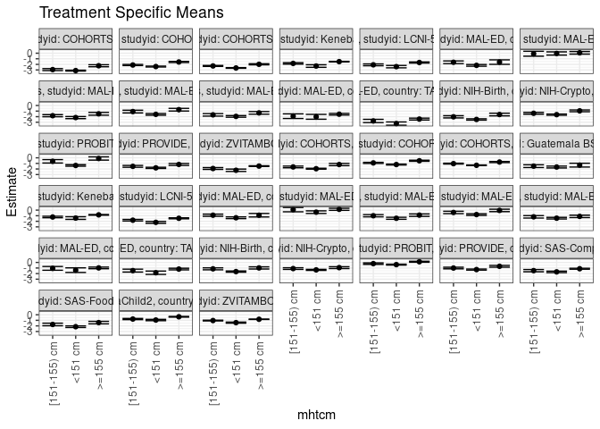

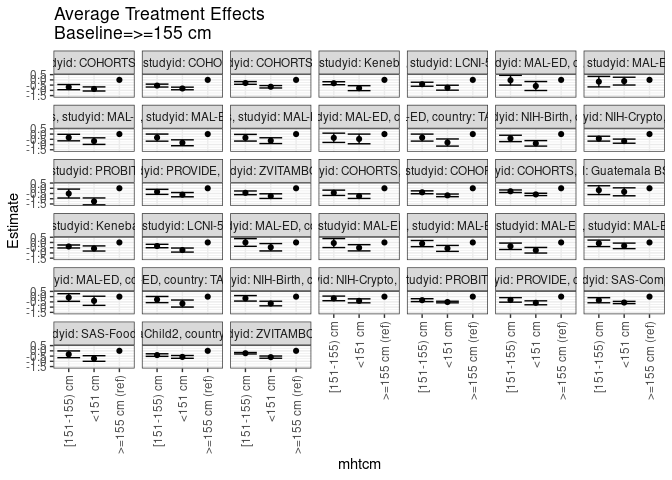

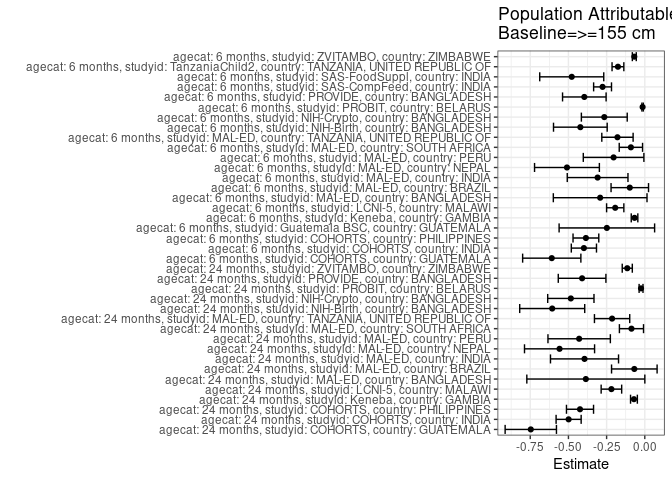

## Results Table

### Parameter: TSM

| agecat | studyid | country | intervention_level | baseline_level | estimate | ci_lower | ci_upper |
| --- | --- | --- | --- | --- | --- | --- | --- |
| 6 months | COHORTS | GUATEMALA | >=155 cm | NA | -1.2024114 | -1.4043734 | -1.0004493 |
| 6 months | COHORTS | GUATEMALA | <151 cm | NA | -1.9533860 | -2.0373227 | -1.8694492 |
| 6 months | COHORTS | GUATEMALA | [151-155) cm | NA | -1.6348040 | -1.7881537 | -1.4814542 |
| 6 months | COHORTS | INDIA | >=155 cm | NA | -0.5266576 | -0.6230234 | -0.4302918 |
| 6 months | COHORTS | INDIA | <151 cm | NA | -1.2042298 | -1.2832645 | -1.1251951 |
| 6 months | COHORTS | INDIA | [151-155) cm | NA | -0.9123387 | -1.0099616 | -0.8147159 |
| 6 months | COHORTS | PHILIPPINES | >=155 cm | NA | -0.7549822 | -0.8476679 | -0.6622964 |
| 6 months | COHORTS | PHILIPPINES | <151 cm | NA | -1.3417141 | -1.3993776 | -1.2840506 |
| 6 months | COHORTS | PHILIPPINES | [151-155) cm | NA | -1.0411061 | -1.1203256 | -0.9618866 |
| 6 months | Guatemala BSC | GUATEMALA | >=155 cm | NA | -1.3115437 | -1.6521048 | -0.9709826 |
| 6 months | Guatemala BSC | GUATEMALA | <151 cm | NA | -1.6506728 | -1.8197063 | -1.4816393 |
| 6 months | Guatemala BSC | GUATEMALA | [151-155) cm | NA | -1.4933692 | -1.7390419 | -1.2476964 |
| 6 months | Keneba | GAMBIA | >=155 cm | NA | -0.8487875 | -0.9013491 | -0.7962258 |
| 6 months | Keneba | GAMBIA | <151 cm | NA | -1.4230833 | -1.6616933 | -1.1844733 |
| 6 months | Keneba | GAMBIA | [151-155) cm | NA | -1.2326644 | -1.3650331 | -1.1002958 |
| 6 months | LCNI-5 | MALAWI | >=155 cm | NA | -1.4641355 | -1.5514255 | -1.3768456 |
| 6 months | LCNI-5 | MALAWI | <151 cm | NA | -2.1907469 | -2.3633208 | -2.0181730 |
| 6 months | LCNI-5 | MALAWI | [151-155) cm | NA | -1.8045519 | -1.9419693 | -1.6671345 |
| 6 months | MAL-ED | BANGLADESH | >=155 cm | NA | -0.9127869 | -1.2282791 | -0.5972947 |
| 6 months | MAL-ED | BANGLADESH | <151 cm | NA | -1.3712254 | -1.5252638 | -1.2171869 |
| 6 months | MAL-ED | BANGLADESH | [151-155) cm | NA | -0.9127145 | -1.1044807 | -0.7209482 |
| 6 months | MAL-ED | BRAZIL | >=155 cm | NA | 0.1457975 | -0.0432069 | 0.3348020 |
| 6 months | MAL-ED | BRAZIL | <151 cm | NA | -0.3640310 | -0.5942877 | -0.1337743 |
| 6 months | MAL-ED | BRAZIL | [151-155) cm | NA | 0.0886894 | -0.2987417 | 0.4761206 |
| 6 months | MAL-ED | INDIA | >=155 cm | NA | -0.8970239 | -1.1137845 | -0.6802633 |
| 6 months | MAL-ED | INDIA | <151 cm | NA | -1.4636369 | -1.6448871 | -1.2823866 |
| 6 months | MAL-ED | INDIA | [151-155) cm | NA | -1.0051677 | -1.2029445 | -0.8073909 |
| 6 months | MAL-ED | NEPAL | >=155 cm | NA | -0.0519305 | -0.2713529 | 0.1674920 |
| 6 months | MAL-ED | NEPAL | <151 cm | NA | -0.7957269 | -0.9436564 | -0.6477975 |
| 6 months | MAL-ED | NEPAL | [151-155) cm | NA | -0.4177391 | -0.6329184 | -0.2025598 |

[output cut: 84 more lines]

### Parameter: E(Y)

| agecat | studyid | country | intervention_level | baseline_level | estimate | ci_lower | ci_upper |
| --- | --- | --- | --- | --- | --- | --- | --- |
| 6 months | COHORTS | GUATEMALA | NA | NA | -1.8116225 | -1.8800533 | -1.7431916 |
| 6 months | COHORTS | INDIA | NA | NA | -0.9254151 | -0.9779952 | -0.8728349 |
| 6 months | COHORTS | PHILIPPINES | NA | NA | -1.1405724 | -1.1824954 | -1.0986493 |
| 6 months | Guatemala BSC | GUATEMALA | NA | NA | -1.5599206 | -1.6885363 | -1.4313049 |
| 6 months | Keneba | GAMBIA | NA | NA | -0.9159303 | -0.9650776 | -0.8667830 |
| 6 months | LCNI-5 | MALAWI | NA | NA | -1.6577751 | -1.7275296 | -1.5880207 |
| 6 months | MAL-ED | BANGLADESH | NA | NA | -1.2049931 | -1.3222136 | -1.0877726 |
| 6 months | MAL-ED | BRAZIL | NA | NA | 0.0475758 | -0.0963508 | 0.1915023 |
| 6 months | MAL-ED | INDIA | NA | NA | -1.2059574 | -1.3243030 | -1.0876119 |
| 6 months | MAL-ED | NEPAL | NA | NA | -0.5615819 | -0.6741832 | -0.4489807 |
| 6 months | MAL-ED | PERU | NA | NA | -1.3241023 | -1.4325083 | -1.2156964 |
| 6 months | MAL-ED | SOUTH AFRICA | NA | NA | -1.0727443 | -1.2024880 | -0.9430006 |
| 6 months | MAL-ED | TANZANIA, UNITED REPUBLIC OF | NA | NA | -1.3687449 | -1.4907629 | -1.2467270 |
| 6 months | NIH-Birth | BANGLADESH | NA | NA | -1.4073821 | -1.4960598 | -1.3187043 |
| 6 months | NIH-Crypto | BANGLADESH | NA | NA | -1.1986783 | -1.2700937 | -1.1272630 |
| 6 months | PROBIT | BELARUS | NA | NA | 0.1077908 | 0.0170166 | 0.1985649 |
| 6 months | PROVIDE | BANGLADESH | NA | NA | -1.0895301 | -1.1639589 | -1.0151013 |
| 6 months | SAS-CompFeed | INDIA | NA | NA | -1.4068893 | -1.4981242 | -1.3156543 |
| 6 months | SAS-FoodSuppl | INDIA | NA | NA | -1.8882058 | -1.9998264 | -1.7765852 |
| 6 months | TanzaniaChild2 | TANZANIA, UNITED REPUBLIC OF | NA | NA | -0.5424553 | -0.5916933 | -0.4932174 |
| 6 months | ZVITAMBO | ZIMBABWE | NA | NA | -0.8803077 | -0.9076731 | -0.8529423 |
| 24 months | COHORTS | GUATEMALA | NA | NA | -2.9963380 | -3.0630990 | -2.9295770 |
| 24 months | COHORTS | INDIA | NA | NA | -2.0710720 | -2.1255079 | -2.0166362 |
| 24 months | COHORTS | PHILIPPINES | NA | NA | -2.4141145 | -2.4590818 | -2.3691473 |
| 24 months | Keneba | GAMBIA | NA | NA | -1.5829641 | -1.6348134 | -1.5311148 |
| 24 months | LCNI-5 | MALAWI | NA | NA | -1.8851820 | -1.9664818 | -1.8038822 |
| 24 months | MAL-ED | BANGLADESH | NA | NA | -1.9783962 | -2.1050210 | -1.8517715 |
| 24 months | MAL-ED | BRAZIL | NA | NA | 0.0061144 | -0.1625850 | 0.1748138 |
| 24 months | MAL-ED | INDIA | NA | NA | -1.8844690 | -2.0097879 | -1.7591502 |
| 24 months | MAL-ED | NEPAL | NA | NA | -1.3075877 | -1.4270718 | -1.1881037 |
| 24 months | MAL-ED | PERU | NA | NA | -1.7524710 | -1.8736426 | -1.6312994 |
| 24 months | MAL-ED | SOUTH AFRICA | NA | NA | -1.6432229 | -1.7795844 | -1.5068615 |
| 24 months | MAL-ED | TANZANIA, UNITED REPUBLIC OF | NA | NA | -2.6455607 | -2.7807256 | -2.5103959 |
| 24 months | NIH-Birth | BANGLADESH | NA | NA | -2.2190579 | -2.3217459 | -2.1163699 |
| 24 months | NIH-Crypto | BANGLADESH | NA | NA | -1.4412646 | -1.5249156 | -1.3576135 |
| 24 months | PROBIT | BELARUS | NA | NA | -0.1444149 | -0.4258602 | 0.1370304 |
| 24 months | PROVIDE | BANGLADESH | NA | NA | -1.6002600 | -1.6836163 | -1.5169036 |
| 24 months | ZVITAMBO | ZIMBABWE | NA | NA | -1.5981623 | -1.6603107 | -1.5360139 |

### Parameter: ATE

| agecat | studyid | country | intervention_level | baseline_level | estimate | ci_lower | ci_upper |
| --- | --- | --- | --- | --- | --- | --- | --- |
| 6 months | COHORTS | GUATEMALA | >=155 cm | >=155 cm | 0.0000000 | 0.0000000 | 0.0000000 |
| 6 months | COHORTS | GUATEMALA | <151 cm | >=155 cm | -0.7509746 | -0.9702839 | -0.5316653 |
| 6 months | COHORTS | GUATEMALA | [151-155) cm | >=155 cm | -0.4323926 | -0.6860594 | -0.1787258 |
| 6 months | COHORTS | INDIA | >=155 cm | >=155 cm | 0.0000000 | 0.0000000 | 0.0000000 |
| 6 months | COHORTS | INDIA | <151 cm | >=155 cm | -0.6775722 | -0.8026879 | -0.5524565 |
| 6 months | COHORTS | INDIA | [151-155) cm | >=155 cm | -0.3856812 | -0.5231434 | -0.2482189 |
| 6 months | COHORTS | PHILIPPINES | >=155 cm | >=155 cm | 0.0000000 | 0.0000000 | 0.0000000 |
| 6 months | COHORTS | PHILIPPINES | <151 cm | >=155 cm | -0.5867319 | -0.6964884 | -0.4769754 |
| 6 months | COHORTS | PHILIPPINES | [151-155) cm | >=155 cm | -0.2861240 | -0.4086935 | -0.1635544 |
| 6 months | Guatemala BSC | GUATEMALA | >=155 cm | >=155 cm | 0.0000000 | 0.0000000 | 0.0000000 |
| 6 months | Guatemala BSC | GUATEMALA | <151 cm | >=155 cm | -0.3391291 | -0.7199419 | 0.0416837 |
| 6 months | Guatemala BSC | GUATEMALA | [151-155) cm | >=155 cm | -0.1818255 | -0.6029727 | 0.2393218 |
| 6 months | Keneba | GAMBIA | >=155 cm | >=155 cm | 0.0000000 | 0.0000000 | 0.0000000 |
| 6 months | Keneba | GAMBIA | <151 cm | >=155 cm | -0.5742958 | -0.8176022 | -0.3309893 |
| 6 months | Keneba | GAMBIA | [151-155) cm | >=155 cm | -0.3838770 | -0.5242921 | -0.2434618 |
| 6 months | LCNI-5 | MALAWI | >=155 cm | >=155 cm | 0.0000000 | 0.0000000 | 0.0000000 |
| 6 months | LCNI-5 | MALAWI | <151 cm | >=155 cm | -0.7266114 | -0.9201907 | -0.5330320 |
| 6 months | LCNI-5 | MALAWI | [151-155) cm | >=155 cm | -0.3404164 | -0.5033680 | -0.1774647 |
| 6 months | MAL-ED | BANGLADESH | >=155 cm | >=155 cm | 0.0000000 | 0.0000000 | 0.0000000 |
| 6 months | MAL-ED | BANGLADESH | <151 cm | >=155 cm | -0.4584385 | -0.8097491 | -0.1071278 |
| 6 months | MAL-ED | BANGLADESH | [151-155) cm | >=155 cm | 0.0000724 | -0.3690839 | 0.3692288 |
| 6 months | MAL-ED | BRAZIL | >=155 cm | >=155 cm | 0.0000000 | 0.0000000 | 0.0000000 |
| 6 months | MAL-ED | BRAZIL | <151 cm | >=155 cm | -0.5098286 | -0.8077187 | -0.2119384 |
| 6 months | MAL-ED | BRAZIL | [151-155) cm | >=155 cm | -0.0571081 | -0.4883632 | 0.3741470 |
| 6 months | MAL-ED | INDIA | >=155 cm | >=155 cm | 0.0000000 | 0.0000000 | 0.0000000 |
| 6 months | MAL-ED | INDIA | <151 cm | >=155 cm | -0.5666130 | -0.8490564 | -0.2841695 |
| 6 months | MAL-ED | INDIA | [151-155) cm | >=155 cm | -0.1081438 | -0.4018238 | 0.1855362 |
| 6 months | MAL-ED | NEPAL | >=155 cm | >=155 cm | 0.0000000 | 0.0000000 | 0.0000000 |
| 6 months | MAL-ED | NEPAL | <151 cm | >=155 cm | -0.7437964 | -1.0084769 | -0.4791159 |
| 6 months | MAL-ED | NEPAL | [151-155) cm | >=155 cm | -0.3658086 | -0.6734114 | -0.0582059 |

[output cut: 84 more lines]

### Parameter: PAR

| agecat | studyid | country | intervention_level | baseline_level | estimate | ci_lower | ci_upper |
| --- | --- | --- | --- | --- | --- | --- | --- |
| 6 months | COHORTS | GUATEMALA | >=155 cm | NA | -0.6092111 | -0.7998604 | -0.4185619 |
| 6 months | COHORTS | INDIA | >=155 cm | NA | -0.3987575 | -0.4811925 | -0.3163225 |
| 6 months | COHORTS | PHILIPPINES | >=155 cm | NA | -0.3855902 | -0.4698791 | -0.3013013 |
| 6 months | Guatemala BSC | GUATEMALA | >=155 cm | NA | -0.2483769 | -0.5610772 | 0.0643233 |
| 6 months | Keneba | GAMBIA | >=155 cm | NA | -0.0671428 | -0.0886852 | -0.0456005 |
| 6 months | LCNI-5 | MALAWI | >=155 cm | NA | -0.1936396 | -0.2501549 | -0.1371243 |
| 6 months | MAL-ED | BANGLADESH | >=155 cm | NA | -0.2922062 | -0.5989358 | 0.0145235 |
| 6 months | MAL-ED | BRAZIL | >=155 cm | NA | -0.0982218 | -0.2209119 | 0.0244684 |
| 6 months | MAL-ED | INDIA | >=155 cm | NA | -0.3089335 | -0.5077187 | -0.1101483 |
| 6 months | MAL-ED | NEPAL | >=155 cm | NA | -0.5096515 | -0.7218857 | -0.2974172 |
| 6 months | MAL-ED | PERU | >=155 cm | NA | -0.2043134 | -0.4027191 | -0.0059077 |
| 6 months | MAL-ED | SOUTH AFRICA | >=155 cm | NA | -0.0909679 | -0.1673743 | -0.0145615 |
| 6 months | MAL-ED | TANZANIA, UNITED REPUBLIC OF | >=155 cm | NA | -0.1789872 | -0.2814993 | -0.0764751 |
| 6 months | NIH-Birth | BANGLADESH | >=155 cm | NA | -0.4220055 | -0.5977205 | -0.2462905 |
| 6 months | NIH-Crypto | BANGLADESH | >=155 cm | NA | -0.2651480 | -0.4152478 | -0.1150482 |
| 6 months | PROBIT | BELARUS | >=155 cm | NA | -0.0143048 | -0.0189116 | -0.0096981 |
| 6 months | PROVIDE | BANGLADESH | >=155 cm | NA | -0.3959149 | -0.5385182 | -0.2533116 |
| 6 months | SAS-CompFeed | INDIA | >=155 cm | NA | -0.2765192 | -0.3350426 | -0.2179957 |
| 6 months | SAS-FoodSuppl | INDIA | >=155 cm | NA | -0.4783816 | -0.6880055 | -0.2687576 |
| 6 months | TanzaniaChild2 | TANZANIA, UNITED REPUBLIC OF | >=155 cm | NA | -0.1758028 | -0.2143711 | -0.1372346 |
| 6 months | ZVITAMBO | ZIMBABWE | >=155 cm | NA | -0.0686637 | -0.0815885 | -0.0557390 |
| 24 months | COHORTS | GUATEMALA | >=155 cm | NA | -0.7464849 | -0.9145039 | -0.5784658 |
| 24 months | COHORTS | INDIA | >=155 cm | NA | -0.4987518 | -0.5807985 | -0.4167050 |
| 24 months | COHORTS | PHILIPPINES | >=155 cm | NA | -0.4241890 | -0.5128398 | -0.3355383 |
| 24 months | Keneba | GAMBIA | >=155 cm | NA | -0.0709986 | -0.0933059 | -0.0486914 |
| 24 months | LCNI-5 | MALAWI | >=155 cm | NA | -0.2185899 | -0.2857626 | -0.1514171 |
| 24 months | MAL-ED | BANGLADESH | >=155 cm | NA | -0.3860703 | -0.7724515 | 0.0003109 |
| 24 months | MAL-ED | BRAZIL | >=155 cm | NA | -0.0685266 | -0.2176327 | 0.0805795 |
| 24 months | MAL-ED | INDIA | >=155 cm | NA | -0.3947316 | -0.6175541 | -0.1719091 |
| 24 months | MAL-ED | NEPAL | >=155 cm | NA | -0.5582254 | -0.7876566 | -0.3287941 |
| 24 months | MAL-ED | PERU | >=155 cm | NA | -0.4297662 | -0.6340235 | -0.2255088 |
| 24 months | MAL-ED | SOUTH AFRICA | >=155 cm | NA | -0.0872380 | -0.1662109 | -0.0082651 |
| 24 months | MAL-ED | TANZANIA, UNITED REPUBLIC OF | >=155 cm | NA | -0.2141473 | -0.3296436 | -0.0986510 |
| 24 months | NIH-Birth | BANGLADESH | >=155 cm | NA | -0.6062245 | -0.8190764 | -0.3933727 |
| 24 months | NIH-Crypto | BANGLADESH | >=155 cm | NA | -0.4842180 | -0.6357202 | -0.3327158 |
| 24 months | PROBIT | BELARUS | >=155 cm | NA | -0.0244938 | -0.0372344 | -0.0117532 |
| 24 months | PROVIDE | BANGLADESH | >=155 cm | NA | -0.4105378 | -0.5665204 | -0.2545553 |
| 24 months | ZVITAMBO | ZIMBABWE | >=155 cm | NA | -0.1147221 | -0.1476941 | -0.0817501 |